# §2.3 — Эконометрическая оценка влияния цифровизации на устойчивость национальных экономик

Mukhammadjon

2026-05-30

# 1 Методологические основы

## 1.1 Гипотеза исследования

**Основная гипотеза (H₁):** уровень цифровизации национальной экономики оказывает статистически значимое положительное влияние на ВВП на душу населения и снижает негативный эффект глобальных кризисов.

**Вспомогательная гипотеза (H₂):** величина и значимость этого эффекта статистически значимо различается между развитыми, переходными и развивающимися экономиками.

## 1.2 Спецификация модели (log-log форма)

Зависимая переменная — **натуральный логарифм ВВП на душу населения** в постоянных ценах (константные доллары США 2015 года). Спецификация оценивается **отдельно для каждой из трёх групп стран** — без объединённой выборки.

$$\begin{aligned}
\ln(GDPpc_{it}) = \alpha_i &+ \beta_1 \ln(Internet_{it}) + \beta_2
\ln(GFCF_{it}) \\
&+ \beta_3 Inflation_{it} + \beta_4 Unemployment_{it} + \beta_5
HighTech_{it} \\
&+ \beta_6 Crisis\_COVID_t + \beta_7 Crisis\_Geo_t \\
&+ \beta_8 [\ln(Internet_{it}) \times Crisis\_COVID_t] \\
&+ \beta_9 [\ln(Internet_{it}) \times Crisis\_Geo_t] +
\varepsilon_{it}
\end{aligned}$$

> **Интерпретация коэффициентов (log-log спецификация):**
> - **β₁, β₂** — эластичности: рост internet/GFCF на 1% → изменение GDPpc на β% при прочих равных.
> - **β₃–β₅** — смешанная спецификация (level-log): рост inflation, unemployment или hightech на **1 п.п.** → изменение ln(GDPpc) на β единиц, что соответствует изменению **GDPpc приблизительно на (exp(β) − 1) × 100%**, или при малых β примерно на β × 100%.
> - **β₈, β₉** — дифференциальная эластичность: насколько сильнее (или слабее) связь интернета с ВВП в кризис vs обычный год.

# 2 Подготовка среды

```r
# install.packages(c("WDI","tidyverse","plm","lmtest","car",
#                    "sandwich","stargazer","corrplot","knitr","ggplot2","scales"))
library(WDI); library(tidyverse); library(plm)
library(lmtest); library(car); library(sandwich)
library(stargazer); library(corrplot); library(knitr); library(ggplot2)
library(scales)
```

# 3 Загрузка данных и классификация стран

```r
developed <- c(
  "USA","GBR","DEU","FRA","ITA","ESP","NLD","BEL","AUT","DNK",
  "SWE","FIN","NOR","IRL","PRT","CHE","CAN","JPN","AUS","NZL","ISR","KOR")

transition <- c(
  "EST","POL","CZE","SVK","HUN","SVN","LTU","LVA",
  "KAZ","AZE","GEO","UKR","TUR","BLR","ARM","MDA")

developing <- c(
  "UZB","KGZ","TJK","CHN","IND","BRA","MEX","ZAF","MYS","THA","IDN")

all_countries <- c(developed, transition, developing)

wdi_indicators <- c(
  gdp_pc       = "NY.GDP.PCAP.KD",
  internet     = "IT.NET.USER.ZS",
  gfcf         = "NE.GDI.FTOT.ZS",
  inflation    = "FP.CPI.TOTL.ZG",
  unemployment = "SL.UEM.TOTL.ZS",
  hightech_exp = "TX.VAL.TECH.MF.ZS")

raw_data <- WDI(
  country=all_countries, indicator=wdi_indicators,
  start=2010, end=2024, extra=TRUE)

raw_data <- raw_data %>%
  mutate(country_group = case_when(
    iso3c %in% developed  ~ "Развитые",
    iso3c %in% transition ~ "Переходные",
    iso3c %in% developing ~ "Развивающиеся",
    TRUE ~ NA_character_)) %>%
  filter(!is.na(country_group))

cat("========================================\n")
cat("СОСТАВ ВЫБОРКИ\n")
```

```
## СОСТАВ ВЫБОРКИ
```

```r
cat("========================================\n")
cat("Развитые (22):", paste(sort(developed), collapse=", "), "\n")
```

```
## Развитые (22): AUS, AUT, BEL, CAN, CHE, DEU, DNK, ESP, FIN, FRA, GBR, IRL, ISR, ITA, JPN, KOR, NLD, NOR, NZL, PRT, SWE, USA
```

```r
cat("Переходные (16):", paste(sort(transition), collapse=", "), "\n")
```

```
## Переходные (16): ARM, AZE, BLR, CZE, EST, GEO, HUN, KAZ, LTU, LVA, MDA, POL, SVK, SVN, TUR, UKR
```

```r
cat("Развивающиеся (11):", paste(sort(developing), collapse=", "), "\n")
```

```
## Развивающиеся (11): BRA, CHN, IDN, IND, KGZ, MEX, MYS, THA, TJK, UZB, ZAF
```

```r
cat("Итого: 49 стран, период 2010–2024\n")
```

```
## Итого: 49 стран, период 2010–2024
```

```r
cat("========================================\n\n")
class_table <- raw_data %>%
  select(iso3c, country, country_group) %>% distinct() %>%
  arrange(country_group, country)
kable(class_table, col.names=c("Код","Страна","Группа"),
      caption="Таблица 2.3.1 — Классификация стран выборки")
```

Таблица 2.3.1 — Классификация стран выборки

| Код | Страна | Группа |
| --- | --- | --- |
| ARM | Armenia | Переходные |
| AZE | Azerbaijan | Переходные |
| BLR | Belarus | Переходные |
| CZE | Czechia | Переходные |
| EST | Estonia | Переходные |
| GEO | Georgia | Переходные |
| HUN | Hungary | Переходные |
| KAZ | Kazakhstan | Переходные |
| LVA | Latvia | Переходные |
| LTU | Lithuania | Переходные |
| MDA | Moldova | Переходные |
| POL | Poland | Переходные |
| SVK | Slovak Republic | Переходные |
| SVN | Slovenia | Переходные |
| TUR | Turkiye | Переходные |
| UKR | Ukraine | Переходные |
| BRA | Brazil | Развивающиеся |
| CHN | China | Развивающиеся |
| IND | India | Развивающиеся |
| IDN | Indonesia | Развивающиеся |
| KGZ | Kyrgyz Republic | Развивающиеся |
| MYS | Malaysia | Развивающиеся |
| MEX | Mexico | Развивающиеся |
| ZAF | South Africa | Развивающиеся |
| TJK | Tajikistan | Развивающиеся |
| THA | Thailand | Развивающиеся |
| UZB | Uzbekistan | Развивающиеся |
| AUS | Australia | Развитые |
| AUT | Austria | Развитые |
| BEL | Belgium | Развитые |
| CAN | Canada | Развитые |
| DNK | Denmark | Развитые |
| FIN | Finland | Развитые |
| FRA | France | Развитые |
| DEU | Germany | Развитые |
| IRL | Ireland | Развитые |
| ISR | Israel | Развитые |
| ITA | Italy | Развитые |
| JPN | Japan | Развитые |
| KOR | Korea, Rep. | Развитые |
| NLD | Netherlands | Развитые |
| NZL | New Zealand | Развитые |
| NOR | Norway | Развитые |
| PRT | Portugal | Развитые |
| ESP | Spain | Развитые |
| SWE | Sweden | Развитые |
| CHE | Switzerland | Развитые |
| GBR | United Kingdom | Развитые |
| USA | United States | Развитые |

# 4 Очистка, трансформация, формирование панели

```r
panel_data <- raw_data %>%
  select(country, iso3c, year, country_group,
         gdp_pc, internet, gfcf, inflation, unemployment, hightech_exp) %>%
  arrange(iso3c, year)

# Доля пропусков
miss <- panel_data %>%
  summarise(across(c(gdp_pc, internet, gfcf, inflation, unemployment, hightech_exp),
                   ~round(mean(is.na(.))*100, 1)))
kable(miss, caption="Таблица 2.3.2 — Доля пропусков по переменным, %")
```

Таблица 2.3.2 — Доля пропусков по переменным, %

| gdp_pc | internet | gfcf | inflation | unemployment | hightech_exp |
| --- | --- | --- | --- | --- | --- |
| 0 | 0 | 0.1 | 1.2 | 0.4 | 2.4 |

```r
# Защита от нулей
panel_data <- panel_data %>%
  mutate(gdp_pc   = ifelse(gdp_pc   <= 0, NA_real_, gdp_pc),
         internet = ifelse(internet <= 0, NA_real_, internet),
         gfcf     = ifelse(gfcf     <= 0, NA_real_, gfcf))

# Crisis dummy
panel_data <- panel_data %>%
  mutate(crisis_covid = as.integer(year == 2020),
         crisis_geo   = as.integer(year == 2022))

# Логарифмы
panel_data <- panel_data %>%
  mutate(ln_gdppc     = log(gdp_pc),
         log_internet = log(internet),
         log_gfcf     = log(gfcf))

# Interaction terms
panel_data <- panel_data %>%
  mutate(log_internet_x_covid = log_internet * crisis_covid,
         log_internet_x_geo   = log_internet * crisis_geo)

# hightech — исключить если >40% пропусков
use_hightech <- mean(is.na(panel_data$hightech_exp)) <= 0.4
if (!use_hightech) {
  message("hightech_exp исключён: >40% пропусков")
  panel_data <- panel_data %>% select(-hightech_exp)
}

panel_clean <- panel_data %>% drop_na()

cat("\n═══════════════════════════════════════\n")
```

```
##
## ═══════════════════════════════════════
```

```r
cat("Итоговая выборка:", nrow(panel_clean), "наблюдений,",
    length(unique(panel_clean$iso3c)), "стран\n")
```

```
## Итоговая выборка: 707 наблюдений, 49 стран
```

```r
cat("Период:", min(panel_clean$year), "–", max(panel_clean$year), "\n")
```

```
## Период: 2010 – 2024
```

```r
cat("hightech_exp включён:", use_hightech, "\n")
```

```
## hightech_exp включён: TRUE
```

```r
cat("═══════════════════════════════════════\n")
```

```
## ═══════════════════════════════════════
```

# 5 Описательная статистика

```r
log_vars <- c("ln_gdppc","log_internet","log_gfcf","inflation","unemployment")
if (use_hightech) log_vars <- c(log_vars, "hightech_exp")

desc <- panel_clean %>%
  select(all_of(log_vars)) %>%
  summarise(across(everything(),
    list(N=~sum(!is.na(.)), Mean=~round(mean(.,na.rm=T),3),
         SD=~round(sd(.,na.rm=T),3), Min=~round(min(.,na.rm=T),3),
         Median=~round(median(.,na.rm=T),3), Max=~round(max(.,na.rm=T),3)))) %>%
  pivot_longer(everything(), names_to=c("variable","stat"),
               names_sep="_(?=[^_]+$)", values_to="value") %>%
  pivot_wider(names_from=stat, values_from=value)
kable(desc, caption="Таблица 2.3.3 — Описательная статистика (log-трансформированные переменные)")
```

Таблица 2.3.3 — Описательная статистика (log-трансформированные переменные)

| variable | N | Mean | SD | Min | Median | Max |
| --- | --- | --- | --- | --- | --- | --- |
| ln_gdppc | 707 | 9.735 | 1.093 | 6.870 | 9.886 | 11.491 |
| log_internet | 707 | 4.272 | 0.384 | 2.015 | 4.399 | 4.603 |
| log_gfcf | 707 | 3.133 | 0.208 | 2.486 | 3.126 | 3.974 |
| inflation | 707 | 4.084 | 6.275 | -1.611 | 2.507 | 72.309 |
| unemployment | 707 | 7.238 | 5.017 | 0.249 | 5.770 | 34.007 |
| hightech_exp | 707 | 16.019 | 10.256 | 0.308 | 15.275 | 59.416 |

```r
group_desc <- panel_clean %>% group_by(country_group) %>%
  summarise(N=n(), Стран=n_distinct(iso3c),
    `Ср.ln(GDPpc)`=round(mean(ln_gdppc,na.rm=T),3),
    `SD ln(GDPpc)`=round(sd(ln_gdppc,na.rm=T),3),
    `Ср.интернет%`=round(mean(internet,na.rm=T),1),
    `Ср.инфляция%`=round(mean(inflation,na.rm=T),2),
    `Ср.безработ%`=round(mean(unemployment,na.rm=T),2))
kable(group_desc, caption="Таблица 2.3.4 — Описательная статистика по группам")
```

Таблица 2.3.4 — Описательная статистика по группам

| country_group | N | Стран | Ср.ln(GDPpc) | SD ln(GDPpc) | Ср.интернет% | Ср.инфляция% | Ср.безработ% |
| --- | --- | --- | --- | --- | --- | --- | --- |
| Переходные | 233 | 16 | 9.153 | 0.702 | 72.4 | 6.53 | 8.05 |
| Развивающиеся | 144 | 11 | 8.480 | 0.765 | 55.6 | 4.76 | 7.18 |
| Развитые | 330 | 22 | 10.694 | 0.336 | 86.8 | 2.06 | 6.69 |

```r
group_desc_full <- panel_clean %>%
  group_by(country_group) %>%
  summarise(
    N = n(),
    Стран = n_distinct(iso3c),

    `Mean ln(GDPpc)` = round(mean(ln_gdppc, na.rm = TRUE), 3),
    `SD ln(GDPpc)` = round(sd(ln_gdppc, na.rm = TRUE), 3),
    `Min ln(GDPpc)` = round(min(ln_gdppc, na.rm = TRUE), 3),
    `Median ln(GDPpc)` = round(median(ln_gdppc, na.rm = TRUE), 3),
    `Max ln(GDPpc)` = round(max(ln_gdppc, na.rm = TRUE), 3),

    `Mean internet` = round(mean(internet, na.rm = TRUE), 1),
    `SD internet` = round(sd(internet, na.rm = TRUE), 1),
    `Min internet` = round(min(internet, na.rm = TRUE), 1),
    `Median internet` = round(median(internet, na.rm = TRUE), 1),
    `Max internet` = round(max(internet, na.rm = TRUE), 1),

    `Mean inflation` = round(mean(inflation, na.rm = TRUE), 2),
    `SD inflation` = round(sd(inflation, na.rm = TRUE), 2),
    `Min inflation` = round(min(inflation, na.rm = TRUE), 2),
    `Median inflation` = round(median(inflation, na.rm = TRUE), 2),
    `Max inflation` = round(max(inflation, na.rm = TRUE), 2),

    `Mean unemployment` = round(mean(unemployment, na.rm = TRUE), 2),
    `SD unemployment` = round(sd(unemployment, na.rm = TRUE), 2),
    `Min unemployment` = round(min(unemployment, na.rm = TRUE), 2),
    `Median unemployment` = round(median(unemployment, na.rm = TRUE), 2),
    `Max unemployment` = round(max(unemployment, na.rm = TRUE), 2)
  )

kable(group_desc_full, caption = "Таблица 2.2 - Описательная статистика переменных по группам стран")
```

Таблица 2.2 - Описательная статистика переменных по группам стран

| country_group | N | Стран | Mean ln(GDPpc) | SD ln(GDPpc) | Min ln(GDPpc) | Median ln(GDPpc) | Max ln(GDPpc) | Mean internet | SD internet | Min internet | Median internet | Max internet | Mean inflation | SD inflation | Min inflation | Median inflation | Max inflation | Mean unemployment | SD unemployment | Min unemployment | Median unemployment | Max unemployment |
| --- | --- | --- | --- | --- | --- | --- | --- | --- | --- | --- | --- | --- | --- | --- | --- | --- | --- | --- | --- | --- | --- | --- |
| Переходные | 233 | 16 | 9.153 | 0.702 | 7.647 | 9.382 | 10.171 | 72.4 | 15.9 | 25.0 | 76.1 | 93.8 | 6.53 | 9.73 | -1.40 | 3.73 | 72.31 | 8.05 | 4.58 | 0.79 | 6.88 | 20.20 |
| Развивающиеся | 144 | 11 | 8.480 | 0.765 | 6.870 | 8.714 | 9.482 | 55.6 | 24.3 | 7.5 | 56.7 | 98.0 | 4.76 | 3.48 | -1.61 | 4.09 | 17.52 | 7.18 | 7.58 | 0.25 | 4.55 | 34.01 |
| Развитые | 330 | 22 | 10.694 | 0.336 | 9.831 | 10.690 | 11.491 | 86.8 | 9.3 | 53.3 | 88.8 | 99.8 | 2.06 | 1.98 | -1.14 | 1.68 | 10.00 | 6.69 | 3.67 | 2.35 | 5.70 | 26.09 |

```r
desc_by_group <- panel_clean %>%
  select(country_group, iso3c, ln_gdppc, internet, inflation, unemployment, log_gfcf, hightech_exp) %>%
  pivot_longer(
    cols = c(ln_gdppc, internet, inflation, unemployment, log_gfcf, hightech_exp),
    names_to = "variable",
    values_to = "value"
  ) %>%
  group_by(country_group, variable) %>%
  summarise(
    N = sum(!is.na(value)),
    Стран = n_distinct(iso3c),
    Mean = round(mean(value, na.rm = TRUE), 3),
    SD = round(sd(value, na.rm = TRUE), 3),
    Min = round(min(value, na.rm = TRUE), 3),
    Median = round(median(value, na.rm = TRUE), 3),
    Max = round(max(value, na.rm = TRUE), 3),
    .groups = "drop"
  )

kable(desc_by_group, caption = "Таблица 2.2 - Описательная статистика переменных по группам стран")
```

Таблица 2.2 - Описательная статистика переменных по группам стран

| country_group | variable | N | Стран | Mean | SD | Min | Median | Max |
| --- | --- | --- | --- | --- | --- | --- | --- | --- |
| Переходные | hightech_exp | 233 | 16 | 11.444 | 8.601 | 1.369 | 9.446 | 43.430 |
| Переходные | inflation | 233 | 16 | 6.525 | 9.733 | -1.404 | 3.732 | 72.309 |
| Переходные | internet | 233 | 16 | 72.427 | 15.929 | 25.000 | 76.074 | 93.779 |
| Переходные | ln_gdppc | 233 | 16 | 9.153 | 0.702 | 7.647 | 9.382 | 10.171 |
| Переходные | log_gfcf | 233 | 16 | 3.108 | 0.188 | 2.486 | 3.105 | 3.673 |
| Переходные | unemployment | 233 | 16 | 8.050 | 4.578 | 0.794 | 6.882 | 20.203 |
| Развивающиеся | hightech_exp | 144 | 11 | 18.440 | 14.356 | 0.308 | 13.375 | 59.416 |
| Развивающиеся | inflation | 144 | 11 | 4.759 | 3.477 | -1.611 | 4.085 | 17.524 |
| Развивающиеся | internet | 144 | 11 | 55.597 | 24.257 | 7.500 | 56.739 | 98.021 |
| Развивающиеся | ln_gdppc | 144 | 11 | 8.480 | 0.765 | 6.870 | 8.714 | 9.482 |
| Развивающиеся | log_gfcf | 144 | 11 | 3.237 | 0.295 | 2.573 | 3.213 | 3.786 |
| Развивающиеся | unemployment | 144 | 11 | 7.180 | 7.582 | 0.249 | 4.554 | 34.007 |
| Развитые | hightech_exp | 330 | 22 | 18.193 | 7.863 | 4.073 | 17.803 | 53.518 |
| Развитые | inflation | 330 | 22 | 2.065 | 1.982 | -1.144 | 1.675 | 10.001 |
| Развитые | internet | 330 | 22 | 86.788 | 9.343 | 53.300 | 88.818 | 99.769 |
| Развитые | ln_gdppc | 330 | 22 | 10.694 | 0.336 | 9.831 | 10.690 | 11.491 |
| Развитые | log_gfcf | 330 | 22 | 3.106 | 0.156 | 2.697 | 3.118 | 3.974 |
| Развитые | unemployment | 330 | 22 | 6.690 | 3.671 | 2.351 | 5.695 | 26.094 |

```r
# Описательная статистика по группам в вертикальном формате

vars_for_desc <- c("ln_gdppc", "internet", "log_gfcf", "inflation", "unemployment")

if (use_hightech) {
  vars_for_desc <- c(vars_for_desc, "hightech_exp")
}

desc_by_group <- panel_clean %>%
  select(country_group, iso3c, all_of(vars_for_desc)) %>%
  pivot_longer(
    cols = all_of(vars_for_desc),
    names_to = "variable",
    values_to = "value"
  ) %>%
  group_by(country_group, variable) %>%
  summarise(
    N = sum(!is.na(value)),
    `Стран` = n_distinct(iso3c),
    Mean = round(mean(value, na.rm = TRUE), 3),
    SD = round(sd(value, na.rm = TRUE), 3),
    Min = round(min(value, na.rm = TRUE), 3),
    Median = round(median(value, na.rm = TRUE), 3),
    Max = round(max(value, na.rm = TRUE), 3),
    .groups = "drop"
  ) %>%
  mutate(
    variable = case_when(
      variable == "ln_gdppc" ~ "ln(GDPpc)",
      variable == "internet" ~ "Internet penetration, %",
      variable == "log_gfcf" ~ "ln(GFCF)",
      variable == "inflation" ~ "Inflation, %",
      variable == "unemployment" ~ "Unemployment, %",
      variable == "hightech_exp" ~ "High-tech exports, %",
      TRUE ~ variable
    )
  ) %>%
  rename(
    `Группа стран` = country_group,
    `Переменная` = variable
  )

kable(
  desc_by_group,
  caption = "Таблица 2.2 - Описательная статистика переменных по группам стран",
  align = "llrrrrrrr"
)
```

Таблица 2.2 - Описательная статистика переменных по группам стран

| Группа стран | Переменная | N | Стран | Mean | SD | Min | Median | Max |
| --- | --- | --- | --- | --- | --- | --- | --- | --- |
| Переходные | High-tech exports, % | 233 | 16 | 11.444 | 8.601 | 1.369 | 9.446 | 43.430 |
| Переходные | Inflation, % | 233 | 16 | 6.525 | 9.733 | -1.404 | 3.732 | 72.309 |
| Переходные | Internet penetration, % | 233 | 16 | 72.427 | 15.929 | 25.000 | 76.074 | 93.779 |
| Переходные | ln(GDPpc) | 233 | 16 | 9.153 | 0.702 | 7.647 | 9.382 | 10.171 |
| Переходные | ln(GFCF) | 233 | 16 | 3.108 | 0.188 | 2.486 | 3.105 | 3.673 |
| Переходные | Unemployment, % | 233 | 16 | 8.050 | 4.578 | 0.794 | 6.882 | 20.203 |
| Развивающиеся | High-tech exports, % | 144 | 11 | 18.440 | 14.356 | 0.308 | 13.375 | 59.416 |
| Развивающиеся | Inflation, % | 144 | 11 | 4.759 | 3.477 | -1.611 | 4.085 | 17.524 |
| Развивающиеся | Internet penetration, % | 144 | 11 | 55.597 | 24.257 | 7.500 | 56.739 | 98.021 |
| Развивающиеся | ln(GDPpc) | 144 | 11 | 8.480 | 0.765 | 6.870 | 8.714 | 9.482 |
| Развивающиеся | ln(GFCF) | 144 | 11 | 3.237 | 0.295 | 2.573 | 3.213 | 3.786 |
| Развивающиеся | Unemployment, % | 144 | 11 | 7.180 | 7.582 | 0.249 | 4.554 | 34.007 |
| Развитые | High-tech exports, % | 330 | 22 | 18.193 | 7.863 | 4.073 | 17.803 | 53.518 |
| Развитые | Inflation, % | 330 | 22 | 2.065 | 1.982 | -1.144 | 1.675 | 10.001 |
| Развитые | Internet penetration, % | 330 | 22 | 86.788 | 9.343 | 53.300 | 88.818 | 99.769 |
| Развитые | ln(GDPpc) | 330 | 22 | 10.694 | 0.336 | 9.831 | 10.690 | 11.491 |
| Развитые | ln(GFCF) | 330 | 22 | 3.106 | 0.156 | 2.697 | 3.118 | 3.974 |
| Развитые | Unemployment, % | 330 | 22 | 6.690 | 3.671 | 2.351 | 5.695 | 26.094 |

# 6 ГРАФИК 1 — Boxplot переменных по группам

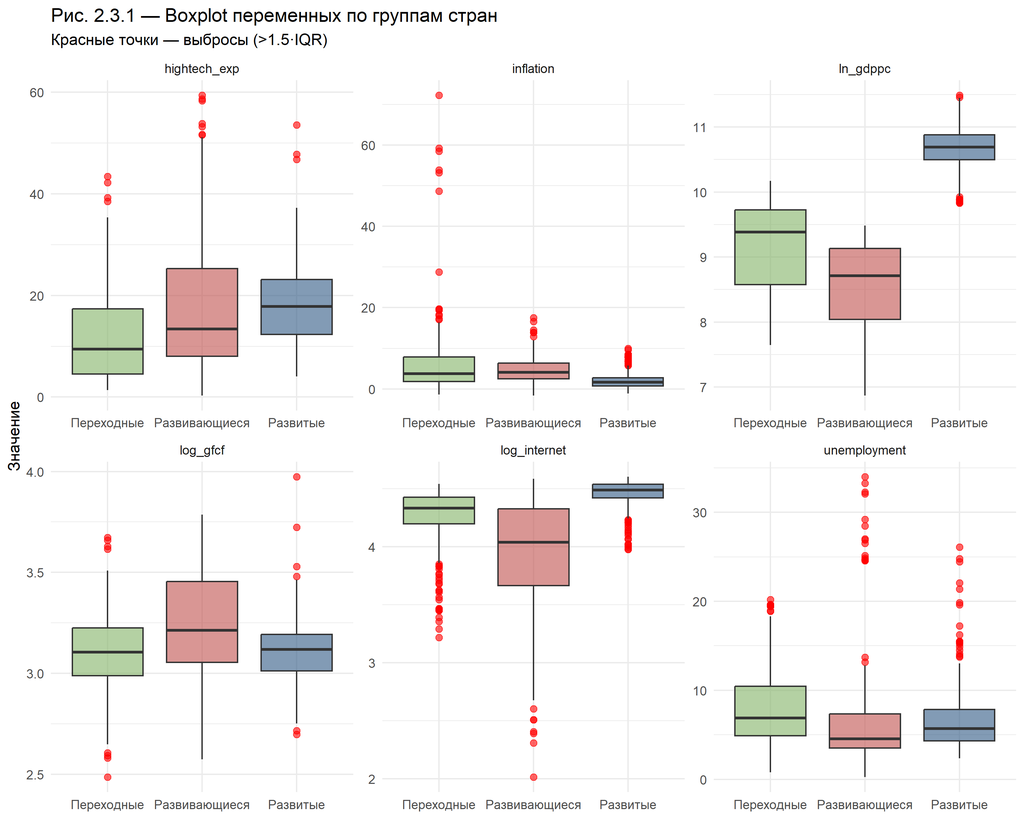

```r
panel_clean %>%
  select(country_group, all_of(log_vars)) %>%
  pivot_longer(-country_group, names_to="variable", values_to="value") %>%
  ggplot(aes(x=country_group, y=value, fill=country_group)) +
  geom_boxplot(alpha=0.6, outlier.color="red", outlier.size=2) +
  facet_wrap(~variable, scales="free", ncol=3) +
  scale_fill_manual(values=c("Развитые"="#2E5984","Переходные"="#82B366","Развивающиеся"="#C0504D")) +
  theme_minimal(base_size=11) + theme(legend.position="none") +
  labs(title="Рис. 2.3.1 — Boxplot переменных по группам стран",
       subtitle="Красные точки — выбросы (>1.5·IQR)", x=NULL, y="Значение")
```

# 7 ГРАФИК 2 — Распределение зависимой переменной

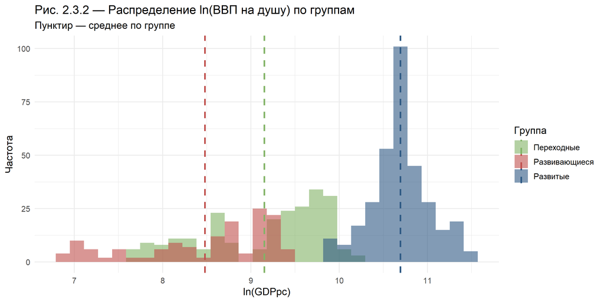

```r
ggplot(panel_clean, aes(x=ln_gdppc, fill=country_group)) +
  geom_histogram(alpha=0.6, bins=30, position="identity") +
  geom_vline(data=panel_clean %>% group_by(country_group) %>%
               summarise(m=mean(ln_gdppc)),
             aes(xintercept=m, color=country_group), linetype="dashed", linewidth=1) +
  scale_fill_manual(values=c("Развитые"="#2E5984","Переходные"="#82B366","Развивающиеся"="#C0504D")) +
  scale_color_manual(values=c("Развитые"="#2E5984","Переходные"="#82B366","Развивающиеся"="#C0504D")) +
  theme_minimal(base_size=12) +
  labs(title="Рис. 2.3.2 — Распределение ln(ВВП на душу) по группам",
       subtitle="Пунктир — среднее по группе",
       x="ln(GDPpc)", y="Частота", fill="Группа", color="Группа")
```

# 8 ГРАФИК 3 — Корреляционные матрицы по группам

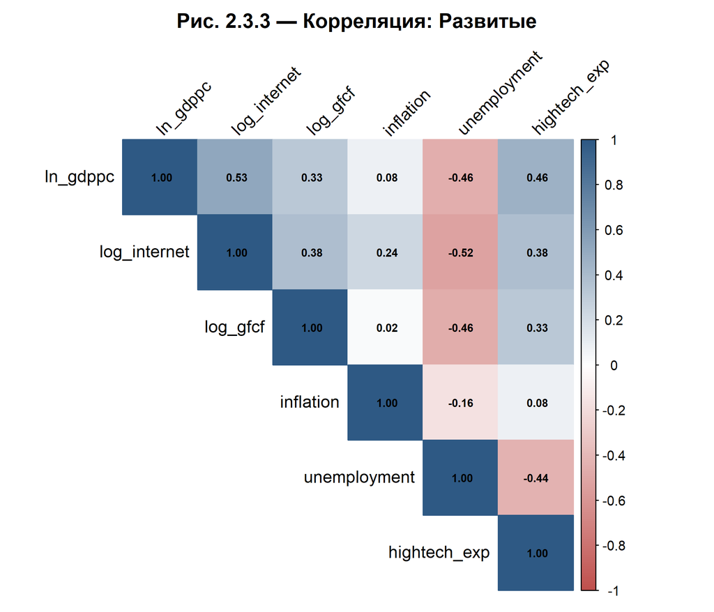

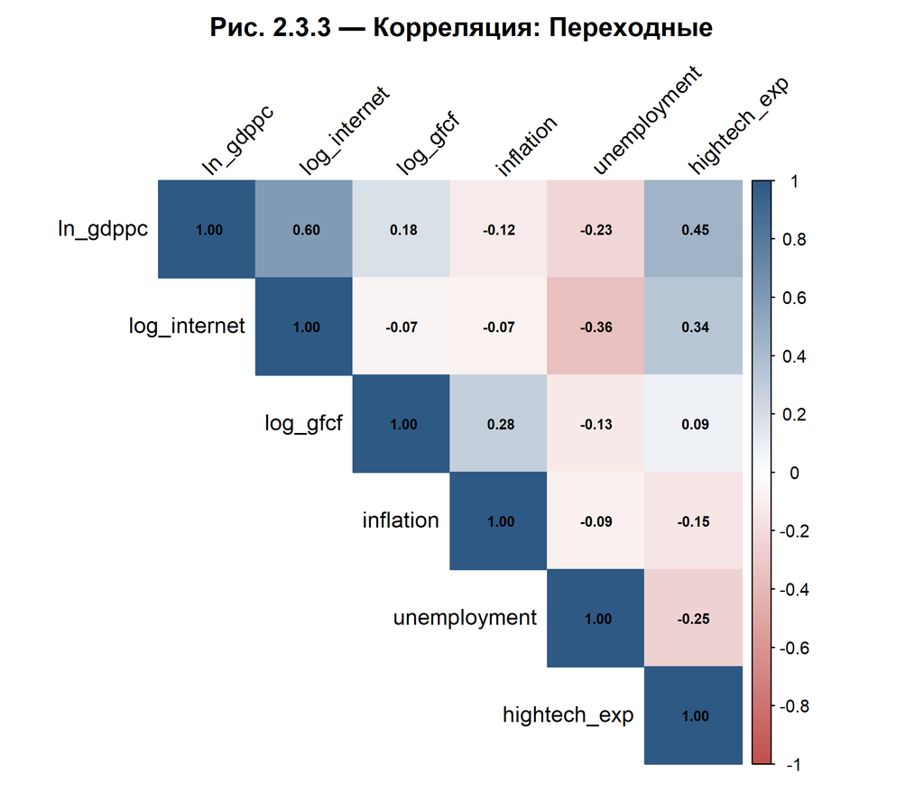

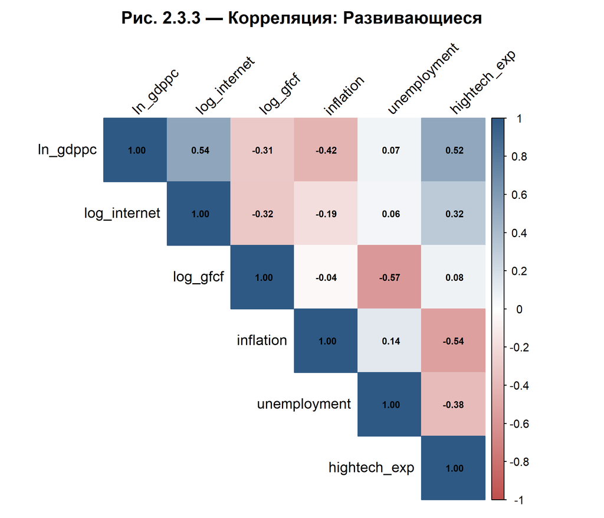

```r
for (g in c("Развитые","Переходные","Развивающиеся")) {
  mat <- panel_clean %>% filter(country_group==g) %>%
    select(all_of(log_vars)) %>% cor(use="pairwise.complete.obs")
  corrplot(mat, method="color", type="upper", addCoef.col="black",
           number.cex=0.65, tl.col="black", tl.srt=45,
           col=colorRampPalette(c("#C0504D","white","#2E5984"))(200),
           title=paste0("Рис. 2.3.3 — Корреляция: ",g), mar=c(0,0,2,0))
}
```

# 9 Тест Чоу — обоснование раздельного анализа

```r
fmla <- if (use_hightech) {
  ln_gdppc ~ log_internet + log_gfcf + inflation + unemployment + hightech_exp +
    crisis_covid + crisis_geo + log_internet_x_covid + log_internet_x_geo
} else {
  ln_gdppc ~ log_internet + log_gfcf + inflation + unemployment +
    crisis_covid + crisis_geo + log_internet_x_covid + log_internet_x_geo
}

pdata_all <- pdata.frame(panel_clean, index=c("iso3c","year"))
model_restricted <- plm(fmla, data=pdata_all, model="within")

groups <- c("Развитые","Переходные","Развивающиеся")
rss_u <- 0; df_u <- 0
for (g in groups) {
  pd_g <- pdata.frame(panel_clean %>% filter(country_group==g), index=c("iso3c","year"))
  fe_g <- plm(fmla, data=pd_g, model="within")
  rss_u <- rss_u + sum(residuals(fe_g)^2)
  df_u  <- df_u  + df.residual(fe_g)
}
rss_r  <- sum(residuals(model_restricted)^2)
k_rest <- (length(groups)-1) * length(coef(model_restricted))
F_chow <- ((rss_r - rss_u)/k_rest) / (rss_u/df_u)
p_chow <- pf(F_chow, k_rest, df_u, lower.tail=FALSE)

kable(data.frame(
  `F`=round(F_chow,4), df1=k_rest, df2=df_u,
  p=format.pval(p_chow, digits=4),
  Вывод=ifelse(p_chow<0.05,"H₀ отвергается → раздельный анализ обоснован","H₀ не отвергается")),
  caption="Таблица 2.3.5 — Тест Чоу на структурную однородность")
```

Таблица 2.3.5 — Тест Чоу на структурную однородность

| F | df1 | df2 | p | Вывод |
| --- | --- | --- | --- | --- |
| 5.3377 | 18 | 631 | 1.151e-11 | H₀ отвергается → раздельный анализ обоснован |

# 10 Диагностика: VIF по каждой группе отдельно

```r
# VIF на полной выборке
vif_all <- car::vif(lm(fmla, data=panel_clean))
kable(data.frame(Variable=names(vif_all), VIF=round(vif_all,3),
  Оценка=ifelse(vif_all<5,"✓ Норма",ifelse(vif_all<10,"⚠ Умеренно","✗ Критично"))),
  caption="Таблица 2.3.6a — VIF (полная выборка)")
```

Таблица 2.3.6a — VIF (полная выборка)

|  | Variable | VIF | Оценка |
| --- | --- | --- | --- |
| log_internet | log_internet | 1.262 | ✓ Норма |
| log_gfcf | log_gfcf | 1.392 | ✓ Норма |
| inflation | inflation | 1.215 | ✓ Норма |
| unemployment | unemployment | 1.395 | ✓ Норма |
| hightech_exp | hightech_exp | 1.332 | ✓ Норма |
| crisis_covid | crisis_covid | 826.341 | ✗ Критично |
| crisis_geo | crisis_geo | 1667.264 | ✗ Критично |
| log_internet_x_covid | log_internet_x_covid | 826.962 | ✗ Критично |
| log_internet_x_geo | log_internet_x_geo | 1668.180 | ✗ Критично |

```r
# VIF по каждой группе
for (g in groups) {
  sub <- panel_clean %>% filter(country_group==g)
  vg <- car::vif(lm(fmla, data=sub))
  cat(sprintf("\n=== VIF: %s (%d наблюдений) ===\n", g, nrow(sub)))
  print(kable(data.frame(Variable=names(vg), VIF=round(vg,3),
    Оценка=ifelse(vg<5,"✓",ifelse(vg<10,"⚠","✗"))),
    caption=paste0("VIF: ",g)))
}
```

```
##
## === VIF: Развитые (330 наблюдений) ===
##
##
## Table: VIF: Развитые
##
## |                     |Variable             |      VIF|Оценка |
## |:--------------------|:--------------------|--------:|:------|
## |log_internet         |log_internet         |    1.596|✓      |
## |log_gfcf             |log_gfcf             |    1.369|✓      |
## |inflation            |inflation            |    1.968|✓      |
## |unemployment         |unemployment         |    1.671|✓      |
## |hightech_exp         |hightech_exp         |    1.344|✓      |
## |crisis_covid         |crisis_covid         | 3955.526|✗      |
## |crisis_geo           |crisis_geo           | 9390.711|✗      |
## |log_internet_x_covid |log_internet_x_covid | 3958.299|✗      |
## |log_internet_x_geo   |log_internet_x_geo   | 9397.712|✗      |
##
## === VIF: Переходные (233 наблюдений) ===
##
##
## Table: VIF: Переходные
##
## |                     |Variable             |      VIF|Оценка |
## |:--------------------|:--------------------|--------:|:------|
## |log_internet         |log_internet         |    1.346|✓      |
## |log_gfcf             |log_gfcf             |    1.163|✓      |
## |inflation            |inflation            |    1.337|✓      |
## |unemployment         |unemployment         |    1.217|✓      |
## |hightech_exp         |hightech_exp         |    1.235|✓      |
## |crisis_covid         |crisis_covid         | 4167.351|✗      |
## |crisis_geo           |crisis_geo           | 4657.105|✗      |
## |log_internet_x_covid |log_internet_x_covid | 4168.420|✗      |
## |log_internet_x_geo   |log_internet_x_geo   | 4655.459|✗      |
##
## === VIF: Развивающиеся (144 наблюдений) ===
##
##
## Table: VIF: Развивающиеся
##
## |                     |Variable             |     VIF|Оценка |
## |:--------------------|:--------------------|-------:|:------|
## |log_internet         |log_internet         |   1.413|✓      |
## |log_gfcf             |log_gfcf             |   1.765|✓      |
## |inflation            |inflation            |   1.472|✓      |
## |unemployment         |unemployment         |   1.825|✓      |
## |hightech_exp         |hightech_exp         |   1.889|✓      |
## |crisis_covid         |crisis_covid         | 439.360|✗      |
## |crisis_geo           |crisis_geo           | 867.920|✗      |
## |log_internet_x_covid |log_internet_x_covid | 439.719|✗      |
## |log_internet_x_geo   |log_internet_x_geo   | 868.742|✗      |
```

# 11 Диагностика остатков — РАЗДЕЛЬНО ПО ГРУППАМ (Исправление Проблемы 1)

```r
cat("═══════════════════════════════════════════════════\n")
```

```
## ═══════════════════════════════════════════════════
```

```r
cat("ДИАГНОСТИКА ОСТАТКОВ ПО КАЖДОЙ ГРУППЕ ОТДЕЛЬНО\n")
```

```
## ДИАГНОСТИКА ОСТАТКОВ ПО КАЖДОЙ ГРУППЕ ОТДЕЛЬНО
```

```r
cat("═══════════════════════════════════════════════════\n\n")
```

```
## ═══════════════════════════════════════════════════
```

```r
for (g in groups) {
  sub <- panel_clean %>% filter(country_group==g)
  pd  <- pdata.frame(sub, index=c("iso3c","year"))
  fe  <- plm(fmla, data=pd, model="within")

  cat(sprintf("──── %s (%d наблюдений, %d стран) ────\n",
              g, nrow(sub), n_distinct(sub$iso3c)))

  # Бройш-Паган
  bp <- bptest(lm(fmla, data=sub))
  cat(sprintf("  Бройш-Паган: BP = %.3f, p = %s → %s\n",
    bp$statistic, format.pval(bp$p.value, digits=3),
    ifelse(bp$p.value<0.05, "гетероскедастичность ВЫЯВЛЕНА → HC1 SE",
           "гомоскедастичность не отвергается")))

  # Автокорреляция (Wooldridge/BG для панелей)
  tryCatch({
    bg <- pbgtest(fe)
    cat(sprintf("  Вулдридж (автокорреляция): χ² = %.3f, p = %s → %s\n",
      bg$statistic, format.pval(bg$p.value, digits=3),
      ifelse(bg$p.value<0.05, "автокорреляция ВЫЯВЛЕНА","не выявлена")))
  }, error=function(e) {
    cat("  Вулдридж: не применим (малая выборка)\n")
  })

  # Нормальность остатков
  res <- residuals(fe)
  if (length(res) < 5000) {
    sw <- shapiro.test(as.numeric(res))
    cat(sprintf("  Шапиро-Уилк (нормальность): W = %.4f, p = %s\n",
      sw$statistic, format.pval(sw$p.value, digits=3)))
  }
  cat("\n")
}
```

```
## ──── Развитые (330 наблюдений, 22 стран) ────
##   Бройш-Паган: BP = 87.210, p = 5.9e-15 → гетероскедастичность ВЫЯВЛЕНА → HC1 SE
##   Вулдридж (автокорреляция): χ² = 183.324, p = <2e-16 → автокорреляция ВЫЯВЛЕНА
##   Шапиро-Уилк (нормальность): W = 0.8942, p = 2.26e-14
##
## ──── Переходные (233 наблюдений, 16 стран) ────
##   Бройш-Паган: BP = 38.888, p = 1.21e-05 → гетероскедастичность ВЫЯВЛЕНА → HC1 SE
##   Вулдридж (автокорреляция): χ² = 108.947, p = <2e-16 → автокорреляция ВЫЯВЛЕНА
##   Шапиро-Уилк (нормальность): W = 0.9623, p = 7.97e-06
##
## ──── Развивающиеся (144 наблюдений, 11 стран) ────
##   Бройш-Паган: BP = 11.790, p = 0.225 → гомоскедастичность не отвергается
##   Вулдридж (автокорреляция): χ² = 88.143, p = <2e-16 → автокорреляция ВЫЯВЛЕНА
##   Шапиро-Уилк (нормальность): W = 0.9253, p = 7.39e-07
```

# 12 ГРАФИК 4 — Остатки FE-моделей: QQ-plot по группам

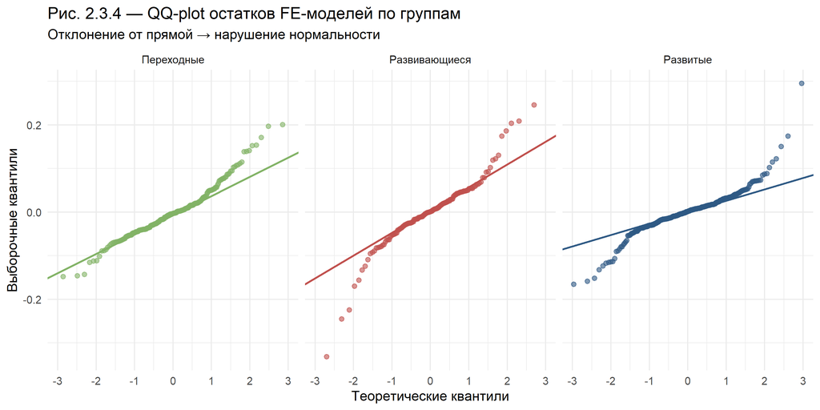

```r
res_data <- bind_rows(
  data.frame(residual=as.numeric(residuals(plm(fmla, data=pdata.frame(
    panel_clean %>% filter(country_group=="Развитые"), index=c("iso3c","year")),
    model="within"))), group="Развитые"),
  data.frame(residual=as.numeric(residuals(plm(fmla, data=pdata.frame(
    panel_clean %>% filter(country_group=="Переходные"), index=c("iso3c","year")),
    model="within"))), group="Переходные"),
  data.frame(residual=as.numeric(residuals(plm(fmla, data=pdata.frame(
    panel_clean %>% filter(country_group=="Развивающиеся"), index=c("iso3c","year")),
    model="within"))), group="Развивающиеся"))

ggplot(res_data, aes(sample=residual, color=group)) +
  stat_qq(alpha=0.6) + stat_qq_line(linewidth=0.8) +
  facet_wrap(~group) +
  scale_color_manual(values=c("Развитые"="#2E5984","Переходные"="#82B366","Развивающиеся"="#C0504D")) +
  theme_minimal(base_size=12) + theme(legend.position="none") +
  labs(title="Рис. 2.3.4 — QQ-plot остатков FE-моделей по группам",
       subtitle="Отклонение от прямой → нарушение нормальности",
       x="Теоретические квантили", y="Выборочные квантили")
```

# 13 ГРАФИК 5 — Гистограмма остатков

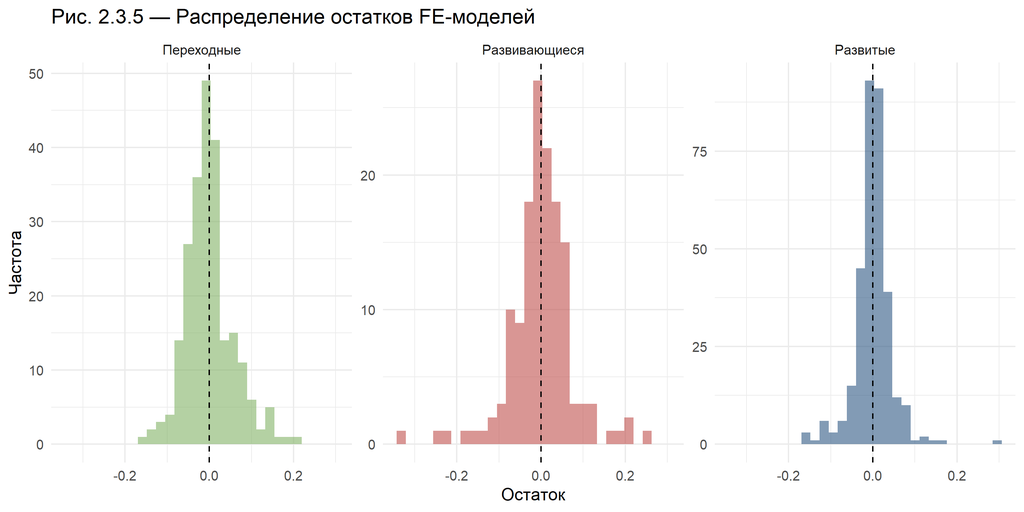

```r
ggplot(res_data, aes(x=residual, fill=group)) +
  geom_histogram(bins=30, alpha=0.6, position="identity") +
  facet_wrap(~group, scales="free_y") +
  scale_fill_manual(values=c("Развитые"="#2E5984","Переходные"="#82B366","Развивающиеся"="#C0504D")) +
  geom_vline(xintercept=0, linetype="dashed") +
  theme_minimal(base_size=12) + theme(legend.position="none") +
  labs(title="Рис. 2.3.5 — Распределение остатков FE-моделей",
       x="Остаток", y="Частота")
```

# 14 Тест Хаусмана — ОСОЗНАННЫЙ ВЫБОР FE (Исправление Проблемы 2)

```r
cat("═══════════════════════════════════════════════════════════\n")
```

```
## ═══════════════════════════════════════════════════════════
```

```r
cat("ТЕСТ ХАУСМАНА И ОБОСНОВАНИЕ ВЫБОРА МОДЕЛИ\n")
```

```
## ТЕСТ ХАУСМАНА И ОБОСНОВАНИЕ ВЫБОРА МОДЕЛИ
```

```r
cat("═══════════════════════════════════════════════════════════\n\n")
```

```
## ═══════════════════════════════════════════════════════════
```

```r
hausman_results <- list()

for (g in groups) {
  sub <- panel_clean %>% filter(country_group==g)
  pd  <- pdata.frame(sub, index=c("iso3c","year"))
  fe  <- plm(fmla, data=pd, model="within")

  tryCatch({
    re <- plm(fmla, data=pd, model="random")
    ht <- phtest(fe, re)
    hausman_results[[g]] <- list(chi2=ht$statistic, p=ht$p.value,
                                 formal=ifelse(ht$p.value<0.05,"FE","RE"))
    cat(sprintf("[%s] Хаусман: χ² = %.3f, p = %s\n",
        g, ht$statistic, format.pval(ht$p.value, digits=3)))
    cat(sprintf("  Формальная рекомендация: %s\n",
        ifelse(ht$p.value<0.05, "Fixed Effects", "Random Effects")))
  }, error=function(e) {
    hausman_results[[g]] <<- list(chi2=NA, p=NA, formal="FE (RE не идентиф.)")
    cat(sprintf("[%s] RE не идентифицирована (сингулярная матрица)\n", g))
  })
}
```

```
## [Развитые] Хаусман: χ² = 4.576, p = 0.87
##   Формальная рекомендация: Random Effects
## [Переходные] Хаусман: χ² = 1.363, p = 0.998
##   Формальная рекомендация: Random Effects
## [Развивающиеся] RE не идентифицирована (сингулярная матрица)
```

```r
cat("\n───────────────────────────────────────────────────────────\n")
cat("РЕШЕНИЕ: во всех трёх группах используется Fixed Effects.\n\n")
```

```
## РЕШЕНИЕ: во всех трёх группах используется Fixed Effects.
```

```r
cat("ОБОСНОВАНИЕ (даже если тест Хаусмана формально указывает на RE):\n\n")
```

```
## ОБОСНОВАНИЕ (даже если тест Хаусмана формально указывает на RE):
```

```r
cat("  1. КОНСИСТЕНТНОСТЬ: для группы «Развивающиеся» RE не\n")
```

```
##   1. КОНСИСТЕНТНОСТЬ: для группы «Развивающиеся» RE не
```

```r
cat("     идентифицирована (сингулярная матрица из-за малой выборки,\n")
```

```
##      идентифицирована (сингулярная матрица из-за малой выборки,
```

```r
cat("     144 наблюдения). FE — единственная доступная модель.\n")
```

```
##      144 наблюдения). FE — единственная доступная модель.
```

```r
cat("     Использование RE для двух групп и FE для третьей\n")
```

```
##      Использование RE для двух групп и FE для третьей
```

```r
cat("     нарушает сопоставимость результатов между группами.\n\n")
```

```
##      нарушает сопоставимость результатов между группами.
```

```r
cat("  2. ТЕОРИЯ: страновая гетерогенность (качество институтов,\n")
```

```
##   2. ТЕОРИЯ: страновая гетерогенность (качество институтов,
```

```r
cat("     географическое положение, историческая траектория)\n")
```

```
##      географическое положение, историческая траектория)
```

```r
cat("     коррелирует с уровнем цифровизации. FE поглощает\n")
```

```
##      коррелирует с уровнем цифровизации. FE поглощает
```

```r
cat("     эту корреляцию, RE — нет (Wooldridge 2010, p. 286).\n\n")
```

```
##      эту корреляцию, RE — нет (Wooldridge 2010, p. 286).
```

```r
cat("  3. ЧУВСТВИТЕЛЬНОСТЬ ХАУСМАНА: тест чувствителен к\n")
```

```
##   3. ЧУВСТВИТЕЛЬНОСТЬ ХАУСМАНА: тест чувствителен к
```

```r
cat("     гетероскедастичности (выявлена BP-тестом). При наличии\n")
```

```
##      гетероскедастичности (выявлена BP-тестом). При наличии
```

```r
cat("     гетероскедастичности Хаусман может давать ложно высокие\n")
```

```
##      гетероскедастичности Хаусман может давать ложно высокие
```

```r
cat("     p-value, рекомендуя RE ошибочно.\n\n")
```

```
##      p-value, рекомендуя RE ошибочно.
```

```r
cat("  4. ПРАКТИКА: в панельных исследованиях кросс-страновых\n")
```

```
##   4. ПРАКТИКА: в панельных исследованиях кросс-страновых
```

```r
cat("     различий в цифровизации (OECD 2016, Czernich et al. 2011)\n")
```

```
##      различий в цифровизации (OECD 2016, Czernich et al. 2011)
```

```r
cat("     стандартным выбором является FE.\n")
```

```
##      стандартным выбором является FE.
```

```r
cat("───────────────────────────────────────────────────────────\n")
```

# 15 Вспомогательные функции

```r
get_robust_se <- function(m) sqrt(diag(vcovHC(m, type="HC1", cluster="group")))
get_ct <- function(m) coeftest(m, vcov=vcovHC(m, type="HC1", cluster="group"))
run_fe <- function(data_group) {
  pd <- pdata.frame(data_group, index=c("iso3c","year"))
  plm(fmla, data=pd, model="within")
}
```

# 16 FE-модели по трём группам

## 16.1 Группа 1 — Развитые страны

```r
data_dev <- panel_clean %>% filter(country_group=="Развитые")
fe_dev   <- run_fe(data_dev)
ct_dev   <- get_ct(fe_dev)
cat("=== FE: Развитые (N=", nobs(fe_dev), ", стран:", n_distinct(data_dev$iso3c), ") ===\n\n")
```

```
## === FE: Развитые (N= 330 , стран: 22 ) ===
```

```r
print(ct_dev)
```

```
##
## t test of coefficients:
##
##                        Estimate Std. Error t value Pr(>|t|)
## log_internet          0.2117042  0.1074268  1.9707 0.049682 *
## log_gfcf              0.1691193  0.0585559  2.8882 0.004158 **
## inflation             0.0035587  0.0018371  1.9372 0.053665 .
## unemployment         -0.0145415  0.0091846 -1.5832 0.114422
## hightech_exp          0.0066570  0.0029907  2.2259 0.026764 *
## crisis_covid         -1.7942163  0.5765121 -3.1122 0.002037 **
## crisis_geo           -1.7869332  0.7650461 -2.3357 0.020167 *
## log_internet_x_covid  0.3940109  0.1297409  3.0369 0.002601 **
## log_internet_x_geo    0.3942770  0.1687495  2.3365 0.020128 *
## ---
## Signif. codes:  0 '***' 0.001 '**' 0.01 '*' 0.05 '.' 0.1 ' ' 1
```

## 16.2 Группа 2 — Переходные экономики

```r
data_tran <- panel_clean %>% filter(country_group=="Переходные")
fe_tran   <- run_fe(data_tran)
ct_tran   <- get_ct(fe_tran)
cat("=== FE: Переходные (N=", nobs(fe_tran), ", стран:", n_distinct(data_tran$iso3c), ") ===\n\n")
```

```
## === FE: Переходные (N= 233 , стран: 16 ) ===
```

```r
print(ct_tran)
```

```
##
## t test of coefficients:
##
##                         Estimate  Std. Error t value  Pr(>|t|)
## log_internet          0.30853950  0.05376118  5.7391 3.334e-08 ***
## log_gfcf              0.06326722  0.06847536  0.9239   0.35659
## inflation             0.00203768  0.00084273  2.4179   0.01647 *
## unemployment         -0.02821181  0.00332188 -8.4927 3.846e-15 ***
## hightech_exp          0.00235789  0.00202144  1.1664   0.24477
## crisis_covid         -0.51229067  1.11528502 -0.4593   0.64647
## crisis_geo            0.56801396  0.75461419  0.7527   0.45247
## log_internet_x_covid  0.11054966  0.25165796  0.4393   0.66091
## log_internet_x_geo   -0.12515710  0.16748693 -0.7473   0.45575
## ---
## Signif. codes:  0 '***' 0.001 '**' 0.01 '*' 0.05 '.' 0.1 ' ' 1
```

## 16.3 Группа 3 — Развивающиеся страны

```r
data_devg <- panel_clean %>% filter(country_group=="Развивающиеся")
fe_devg   <- run_fe(data_devg)
ct_devg   <- get_ct(fe_devg)
cat("=== FE: Развивающиеся (N=", nobs(fe_devg), ", стран:", n_distinct(data_devg$iso3c), ") ===\n\n")
```

```
## === FE: Развивающиеся (N= 144 , стран: 11 ) ===
```

```r
print(ct_devg)
```

```
##
## t test of coefficients:
##
##                        Estimate Std. Error t value  Pr(>|t|)
## log_internet          0.1977755  0.0318540  6.2088 7.370e-09 ***
## log_gfcf             -0.1388158  0.1094946 -1.2678   0.20725
## inflation            -0.0105989  0.0042013 -2.5228   0.01291 *
## unemployment         -0.0253413  0.0047010 -5.3906 3.407e-07 ***
## hightech_exp         -0.0013247  0.0063443 -0.2088   0.83494
## crisis_covid         -0.1334826  0.1847721 -0.7224   0.47140
## crisis_geo           -0.1899435  0.4155750 -0.4571   0.64843
## log_internet_x_covid  0.0184098  0.0471230  0.3907   0.69671
## log_internet_x_geo    0.0456933  0.0977783  0.4673   0.64109
## ---
## Signif. codes:  0 '***' 0.001 '**' 0.01 '*' 0.05 '.' 0.1 ' ' 1
```

```r
cat("\n⚠ ОГРАНИЧЕНИЕ: 144 наблюдения на 11 стран — малая подвыборка\n")
```

```
##
## ⚠ ОГРАНИЧЕНИЕ: 144 наблюдения на 11 стран — малая подвыборка
```

```r
cat("для FE с 9 переменными. Именно поэтому RE не идентифицируется.\n")
```

```
## для FE с 9 переменными. Именно поэтому RE не идентифицируется.
```

```r
cat("Результаты для данной группы интерпретируются с осторожностью.\n")
```

```
## Результаты для данной группы интерпретируются с осторожностью.
```

## 16.4 Сводная таблица трёх групп

```r
stargazer(fe_dev, fe_tran, fe_devg,
  type="text",
  se=list(get_robust_se(fe_dev), get_robust_se(fe_tran), get_robust_se(fe_devg)),
  title="Таблица 2.3.7 — FE-модели по группам, зав. пер.: ln(GDPpc)",
  column.labels=c("Развитые","Переходные","Развивающиеся"),
  digits=4, no.space=TRUE, model.names=FALSE,
  dep.var.labels="ln(GDP per capita, const. 2015 USD)",
  notes=c("SE кластеризованы по странам (HC1).", "*** p<0.01, ** p<0.05, * p<0.1"))
```

```
##
## Таблица 2.3.7 — FE-модели по группам, зав. пер.: ln(GDPpc)
## ================================================================================================
##                                                  Dependent variable:
##                      ---------------------------------------------------------------------------
##                                          ln(GDP per capita, const. 2015 USD)
##                              Развитые                Переходные              Развивающиеся
##                                (1)                       (2)                      (3)
## ------------------------------------------------------------------------------------------------
## log_internet                 0.2117**                 0.3085***                0.1978***
##                              (0.1074)                 (0.0538)                  (0.0319)
## log_gfcf                    0.1691***                  0.0633                   -0.1388
##                              (0.0586)                 (0.0685)                  (0.1095)
## inflation                    0.0036*                  0.0020**                 -0.0106**
##                              (0.0018)                 (0.0008)                  (0.0042)
## unemployment                 -0.0145                 -0.0282***                -0.0253***
##                              (0.0092)                 (0.0033)                  (0.0047)
## hightech_exp                 0.0067**                  0.0024                   -0.0013
##                              (0.0030)                 (0.0020)                  (0.0063)
## crisis_covid                -1.7942***                 -0.5123                  -0.1335
##                              (0.5765)                 (1.1153)                  (0.1848)
## crisis_geo                  -1.7869**                  0.5680                   -0.1899
##                              (0.7650)                 (0.7546)                  (0.4156)
## log_internet_x_covid        0.3940***                  0.1105                    0.0184
##                              (0.1297)                 (0.2517)                  (0.0471)
## log_internet_x_geo           0.3943**                  -0.1252                   0.0457
##                              (0.1687)                 (0.1675)                  (0.0978)
## ------------------------------------------------------------------------------------------------
## Observations                   330                       233                      144
## R2                            0.6642                   0.8278                    0.6574
## Adjusted R2                   0.6305                   0.8079                    0.6049
## F Statistic          65.7126*** (df = 9; 299) 111.1071*** (df = 9; 208) 26.4384*** (df = 9; 124)
## ================================================================================================
## Note:                                                                *p<0.1; **p<0.05; ***p<0.01
##                                                              SE кластеризованы по странам (HC1).
##                                                                   *** p<0.01, ** p<0.05, * p<0.1
```

# 17 Интерпретация результатов

```r
cat("════════════════════════════════════════════════════════\n")
```

```
## ════════════════════════════════════════════════════════
```

```r
cat("ИНТЕРПРЕТАЦИЯ КОЭФФИЦИЕНТОВ (фактические результаты)\n")
```

```
## ИНТЕРПРЕТАЦИЯ КОЭФФИЦИЕНТОВ (фактические результаты)
```

```r
cat("════════════════════════════════════════════════════════\n\n")
```

```
## ════════════════════════════════════════════════════════
```

```r
for (g in groups) {
  ct <- switch(g, "Развитые"=ct_dev, "Переходные"=ct_tran, "Развивающиеся"=ct_devg)
  cat(sprintf("──── %s ────\n", g))
  for (var in c("log_internet","log_internet_x_covid","log_internet_x_geo")) {
    if (var %in% rownames(ct)) {
      b <- ct[var,"Estimate"]; p <- ct[var,"Pr(>|t|)"]
      sig <- ifelse(p<0.01,"***",ifelse(p<0.05,"**",ifelse(p<0.10,"*","н/з")))
      effect_10 <- b * log(1.10)
      lbl <- switch(var,
        "log_internet"="Основной эффект интернета",
        "log_internet_x_covid"="Доп. эффект в COVID-2020",
        "log_internet_x_geo"="Доп. эффект в Геокризис-2022")
      cat(sprintf("  %s: β=%.4f %s (p=%.4f)\n", lbl, b, sig, p))
      cat(sprintf("    → +10%% интернета → Δln(GDPpc) ≈ %.4f → ≈ %+.2f%% ВВП на душу\n\n",
                  effect_10, effect_10*100))
    }
  }
}
```

```
## ──── Развитые ────
##   Основной эффект интернета: β=0.2117 ** (p=0.0497)
##     → +10% интернета → Δln(GDPpc) ≈ 0.0202 → ≈ +2.02% ВВП на душу
##
##   Доп. эффект в COVID-2020: β=0.3940 *** (p=0.0026)
##     → +10% интернета → Δln(GDPpc) ≈ 0.0376 → ≈ +3.76% ВВП на душу
##
##   Доп. эффект в Геокризис-2022: β=0.3943 ** (p=0.0201)
##     → +10% интернета → Δln(GDPpc) ≈ 0.0376 → ≈ +3.76% ВВП на душу
##
## ──── Переходные ────
##   Основной эффект интернета: β=0.3085 *** (p=0.0000)
##     → +10% интернета → Δln(GDPpc) ≈ 0.0294 → ≈ +2.94% ВВП на душу
##
##   Доп. эффект в COVID-2020: β=0.1105 н/з (p=0.6609)
##     → +10% интернета → Δln(GDPpc) ≈ 0.0105 → ≈ +1.05% ВВП на душу
##
##   Доп. эффект в Геокризис-2022: β=-0.1252 н/з (p=0.4557)
##     → +10% интернета → Δln(GDPpc) ≈ -0.0119 → ≈ -1.19% ВВП на душу
##
## ──── Развивающиеся ────
##   Основной эффект интернета: β=0.1978 *** (p=0.0000)
##     → +10% интернета → Δln(GDPpc) ≈ 0.0189 → ≈ +1.89% ВВП на душу
##
##   Доп. эффект в COVID-2020: β=0.0184 н/з (p=0.6967)
##     → +10% интернета → Δln(GDPpc) ≈ 0.0018 → ≈ +0.18% ВВП на душу
##
##   Доп. эффект в Геокризис-2022: β=0.0457 н/з (p=0.6411)
##     → +10% интернета → Δln(GDPpc) ≈ 0.0044 → ≈ +0.44% ВВП на душу
```

# 18 ГРАФИК 6 — Interaction terms: сравнение групп (основной график для §2.3)

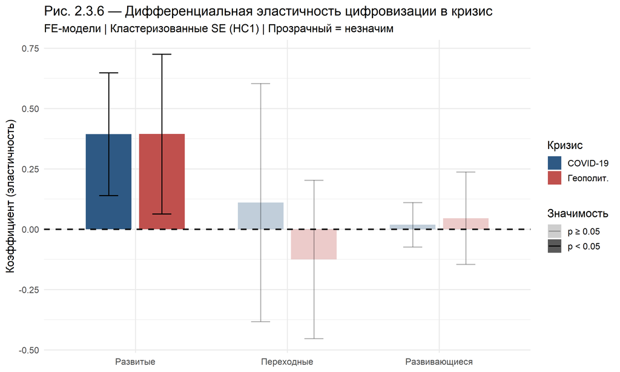

```r
extract_coef <- function(ct, v) {
  if (v %in% rownames(ct)) c(coef=ct[v,"Estimate"], se=ct[v,"Std. Error"], pval=ct[v,"Pr(>|t|)"])
  else c(coef=NA, se=NA, pval=NA)
}

coef_data <- bind_rows(
  data.frame(Group="Развитые",      Crisis="COVID-19",  t(extract_coef(ct_dev,"log_internet_x_covid"))),
  data.frame(Group="Развитые",      Crisis="Геополит.", t(extract_coef(ct_dev,"log_internet_x_geo"))),
  data.frame(Group="Переходные",    Crisis="COVID-19",  t(extract_coef(ct_tran,"log_internet_x_covid"))),
  data.frame(Group="Переходные",    Crisis="Геополит.", t(extract_coef(ct_tran,"log_internet_x_geo"))),
  data.frame(Group="Развивающиеся", Crisis="COVID-19",  t(extract_coef(ct_devg,"log_internet_x_covid"))),
  data.frame(Group="Развивающиеся", Crisis="Геополит.", t(extract_coef(ct_devg,"log_internet_x_geo")))
) %>% mutate(
  Group=factor(Group, levels=c("Развитые","Переходные","Развивающиеся")),
  Signif=!is.na(pval) & pval<0.05,
  ci_low=coef-1.96*se, ci_high=coef+1.96*se)

ggplot(coef_data, aes(x=Group, y=coef, fill=Crisis, alpha=Signif)) +
  geom_col(position=position_dodge(0.7), width=0.6) +
  geom_errorbar(aes(ymin=ci_low, ymax=ci_high), position=position_dodge(0.7), width=0.25) +
  scale_alpha_manual(values=c("TRUE"=1,"FALSE"=0.3), labels=c("p ≥ 0.05","p < 0.05"), name="Значимость") +
  scale_fill_manual(values=c("COVID-19"="#2E5984","Геополит."="#C0504D")) +
  geom_hline(yintercept=0, linetype="dashed", linewidth=0.8) +
  theme_minimal(base_size=13) +
  labs(title="Рис. 2.3.6 — Дифференциальная эластичность цифровизации в кризис",
       subtitle="FE-модели | Кластеризованные SE (HC1) | Прозрачный = незначим",
       x=NULL, y="Коэффициент (эластичность)", fill="Кризис")
```

# 19 ГРАФИК 7 — Все ключевые коэффициенты (Forest plot)

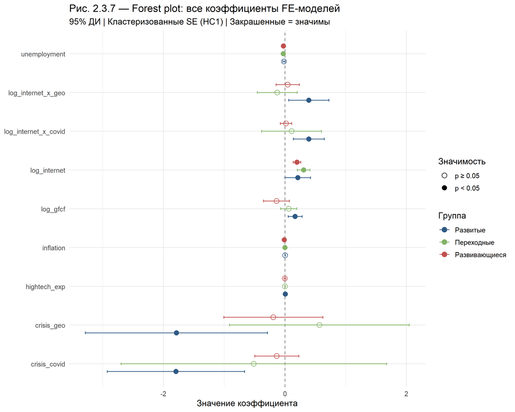

```r
all_coefs <- bind_rows(
  data.frame(group="Развитые",
    variable=rownames(ct_dev),
    est=ct_dev[,"Estimate"], se=ct_dev[,"Std. Error"], p=ct_dev[,"Pr(>|t|)"]),
  data.frame(group="Переходные",
    variable=rownames(ct_tran),
    est=ct_tran[,"Estimate"], se=ct_tran[,"Std. Error"], p=ct_tran[,"Pr(>|t|)"]),
  data.frame(group="Развивающиеся",
    variable=rownames(ct_devg),
    est=ct_devg[,"Estimate"], se=ct_devg[,"Std. Error"], p=ct_devg[,"Pr(>|t|)"])
) %>% mutate(
  sig=p<0.05,
  ci_lo=est-1.96*se, ci_hi=est+1.96*se,
  group=factor(group, levels=c("Развитые","Переходные","Развивающиеся")))

ggplot(all_coefs, aes(x=est, y=variable, color=group, shape=sig)) +
  geom_vline(xintercept=0, linetype="dashed", color="grey50") +
  geom_point(size=3, position=position_dodge(0.6)) +
  geom_errorbarh(aes(xmin=ci_lo, xmax=ci_hi), height=0.2, position=position_dodge(0.6)) +
  scale_color_manual(values=c("Развитые"="#2E5984","Переходные"="#82B366","Развивающиеся"="#C0504D")) +
  scale_shape_manual(values=c("TRUE"=16,"FALSE"=1), labels=c("p ≥ 0.05","p < 0.05")) +
  theme_minimal(base_size=12) +
  labs(title="Рис. 2.3.7 — Forest plot: все коэффициенты FE-моделей",
       subtitle="95% ДИ | Кластеризованные SE (HC1) | Закрашенные = значимы",
       x="Значение коэффициента", y=NULL, color="Группа", shape="Значимость")
```

# 20 ГРАФИК 8 — Динамика ln(GDPpc) и интернета по группам

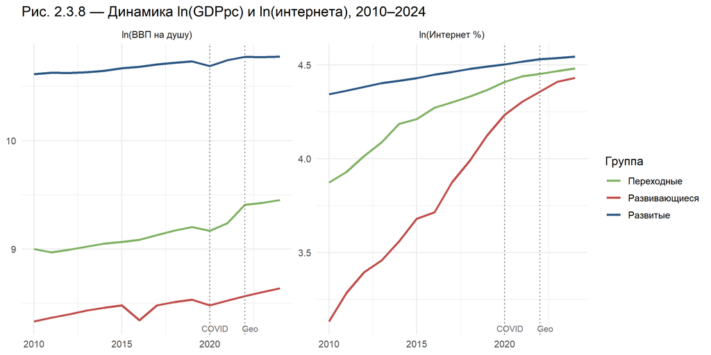

```r
panel_clean %>%
  group_by(country_group, year) %>%
  summarise(mean_gdp=mean(ln_gdppc,na.rm=T), mean_int=mean(log_internet,na.rm=T), .groups="drop") %>%
  pivot_longer(c(mean_gdp,mean_int), names_to="var", values_to="val") %>%
  mutate(var=ifelse(var=="mean_gdp","ln(ВВП на душу)","ln(Интернет %)")) %>%
  ggplot(aes(x=year, y=val, color=country_group)) +
  geom_line(linewidth=1.1) +
  geom_vline(xintercept=c(2020,2022), linetype="dotted", color="grey40") +
  annotate("text",x=2020.3,y=-Inf,vjust=-0.5,label="COVID",size=3,color="grey40") +
  annotate("text",x=2022.3,y=-Inf,vjust=-0.5,label="Geo",size=3,color="grey40") +
  scale_color_manual(values=c("Развитые"="#2E5984","Переходные"="#82B366","Развивающиеся"="#C0504D")) +
  facet_wrap(~var, scales="free_y") +
  theme_minimal(base_size=12) +
  labs(title="Рис. 2.3.8 — Динамика ln(GDPpc) и ln(интернета), 2010–2024",
       x=NULL, y=NULL, color="Группа")
```

# 21 ГРАФИК 9 — Scatter: интернет vs GDPpc в кризисные годы

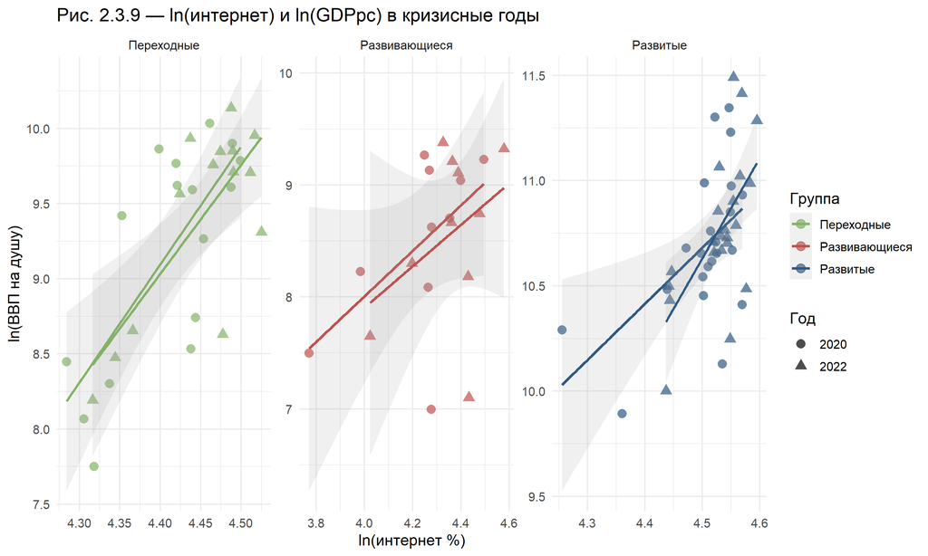

```r
ggplot(panel_clean %>% filter(year %in% c(2020,2022)),
  aes(x=log_internet, y=ln_gdppc, color=country_group, shape=as.factor(year))) +
  geom_point(alpha=0.7, size=3) +
  geom_smooth(method="lm", se=TRUE, linewidth=1, alpha=0.15) +
  scale_color_manual(values=c("Развитые"="#2E5984","Переходные"="#82B366","Развивающиеся"="#C0504D")) +
  facet_wrap(~country_group, scales="free") +
  theme_minimal(base_size=12) +
  labs(title="Рис. 2.3.9 — ln(интернет) и ln(GDPpc) в кризисные годы",
       x="ln(интернет %)", y="ln(ВВП на душу)", color="Группа", shape="Год")
```

# 22 ГРАФИК 10 — Фиксированные эффекты по странам

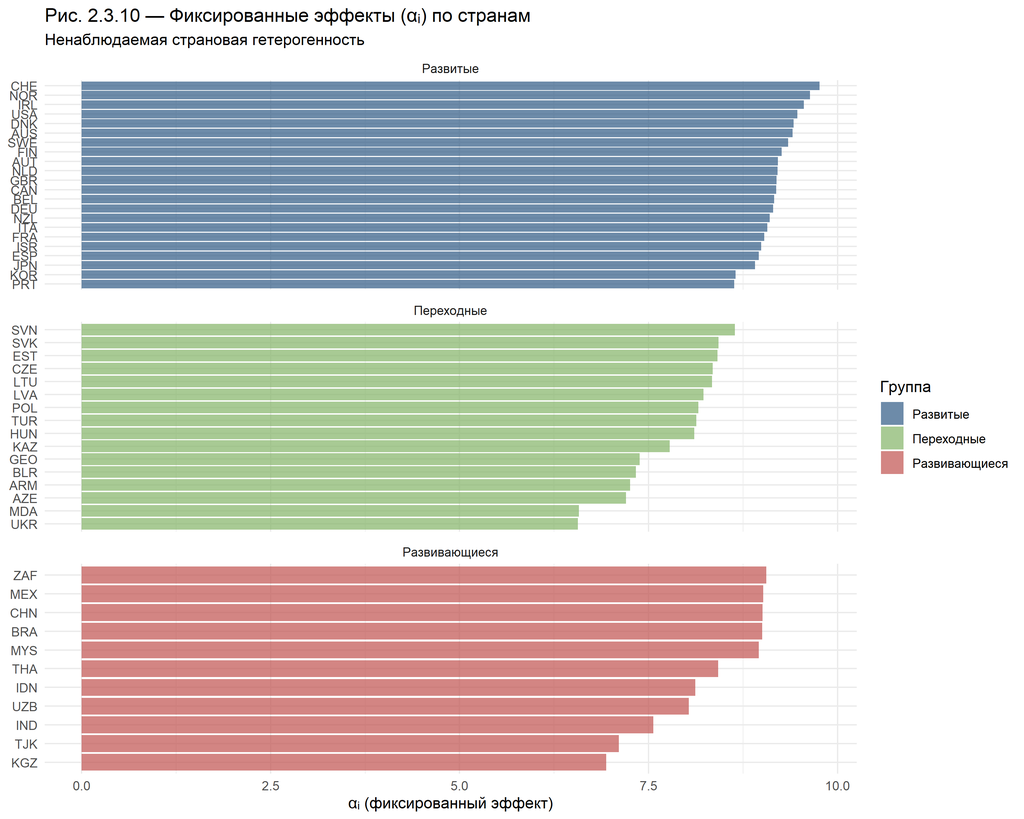

```r
fe_list <- list("Развитые"=fe_dev,"Переходные"=fe_tran,"Развивающиеся"=fe_devg)
fixef_data <- bind_rows(lapply(names(fe_list), function(g) {
  fx <- fixef(fe_list[[g]])
  data.frame(country=names(fx), alpha=as.numeric(fx), group=g)
})) %>% mutate(group=factor(group, levels=c("Развитые","Переходные","Развивающиеся")))

ggplot(fixef_data, aes(x=alpha, y=reorder(country,alpha), fill=group)) +
  geom_col(alpha=0.7) +
  scale_fill_manual(values=c("Развитые"="#2E5984","Переходные"="#82B366","Развивающиеся"="#C0504D")) +
  facet_wrap(~group, scales="free_y", ncol=1) +
  theme_minimal(base_size=11) +
  labs(title="Рис. 2.3.10 — Фиксированные эффекты (αᵢ) по странам",
       subtitle="Ненаблюдаемая страновая гетерогенность",
       x="αᵢ (фиксированный эффект)", y=NULL, fill="Группа")
```

# 23 ГРАФИК 11 — Факт vs Подогнанное (качество моделей)

[figure not shown]

```r
fit_data <- bind_rows(
  data.frame(actual=as.numeric(model.response(model.frame(fe_dev))),
             fitted=as.numeric(fitted(fe_dev)), group="Развитые"),
  data.frame(actual=as.numeric(model.response(model.frame(fe_tran))),
             fitted=as.numeric(fitted(fe_tran)), group="Переходные"),
  data.frame(actual=as.numeric(model.response(model.frame(fe_devg))),
             fitted=as.numeric(fitted(fe_devg)), group="Развивающиеся"))

ggplot(fit_data, aes(x=actual, y=fitted, color=group)) +
  geom_point(alpha=0.5, size=2) +
  geom_abline(slope=1, intercept=0, linetype="dashed", color="black") +
  facet_wrap(~group) +
  scale_color_manual(values=c("Развитые"="#2E5984","Переходные"="#82B366","Развивающиеся"="#C0504D")) +
  theme_minimal(base_size=12) + theme(legend.position="none") +
  labs(title="Рис. 2.3.11 — Факт vs Подогнанное ln(GDPpc)",
       subtitle="Близость к диагонали = хорошее качество подгонки",
       x="Фактическое ln(GDPpc)", y="Подогнанное ln(GDPpc)")
```